# Homework 5

### Step 4

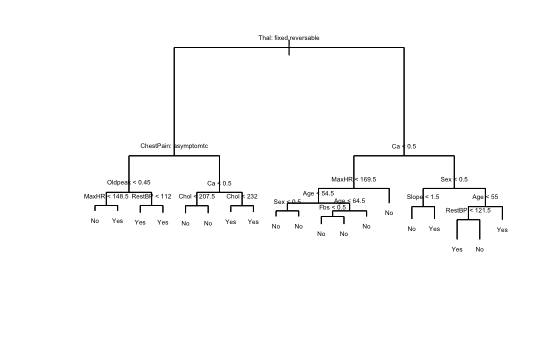

```r
#a
plot(dtreeheart)
text(dtreeheart, cex=0.40, pretty=10)
```

```r
#b
dtreeheart
```

```
node), split, n, deviance, yval, (yprob)
      * denotes terminal node

  1) root 237 328.000 No ( 0.47679 0.52321 )
    2) Thal: fixed,reversable 108 114.400 Yes ( 0.77778 0.22222 )
      4) ChestPain: asymptomatic 70  36.020 Yes ( 0.92857 0.07143 )
        8) Oldpeak < 0.45 14  16.750 Yes ( 0.71429 0.28571 )
         16) MaxHR < 148.5 5   6.730 No ( 0.40000 0.60000 ) *
         17) MaxHR > 148.5 9   6.279 Yes ( 0.88889 0.11111 ) *
        9) Oldpeak > 0.45 56  10.030 Yes ( 0.98214 0.01786 )
         18) RestBP < 112 5   5.004 Yes ( 0.80000 0.20000 ) *
         19) RestBP > 112 51   0.000 Yes ( 1.00000 0.00000 ) *
      5) ChestPain: nonanginal,nontypical,typical 38  52.680 Yes ( 0.50000 0.50000 )
       10) Ca < 0.5 23  28.270 No ( 0.30435 0.69565 )
         20) Chol < 207.5 6   0.000 No ( 0.00000 1.00000 ) *
         21) Chol > 207.5 17  23.030 No ( 0.41176 0.58824 ) *
       11) Ca > 0.5 15  15.010 Yes ( 0.80000 0.20000 )
         22) Chol < 232 8  10.590 Yes ( 0.62500 0.37500 ) *
         23) Chol > 232 7   0.000 Yes ( 1.00000 0.00000 ) *
    3) Thal: normal 129 137.500 No ( 0.22481 0.77519 )
      6) Ca < 0.5 92  63.260 No ( 0.10870 0.89130 )
       12) MaxHR < 169.5 57  52.940 No ( 0.17544 0.82456 )
         24) Age < 54.5 30  14.700 No ( 0.06667 0.93333 )
           48) Sex < 0.5 18   0.000 No ( 0.00000 1.00000 ) *
           49) Sex > 0.5 12  10.810 No ( 0.16667 0.83333 ) *
         25) Age > 54.5 27  32.820 No ( 0.29630 0.70370 )
           50) Age < 64.5 22  28.840 No ( 0.36364 0.63636 )
            100) Fbs < 0.5 17  23.510 No ( 0.47059 0.52941 ) *
            101) Fbs > 0.5 5   0.000 No ( 0.00000 1.00000 ) *
           51) Age > 64.5 5   0.000 No ( 0.00000 1.00000 ) *
       13) MaxHR > 169.5 35   0.000 No ( 0.00000 1.00000 ) *
      7) Ca > 0.5 37  51.270 Yes ( 0.51351 0.48649 )
       14) Sex < 0.5 16  15.440 No ( 0.18750 0.81250 )
         28) Slope < 1.5 11   0.000 No ( 0.00000 1.00000 ) *
         29) Slope > 1.5 5   6.730 Yes ( 0.60000 0.40000 ) *
       15) Sex > 0.5 21  23.050 Yes ( 0.76190 0.23810 )
         30) Age < 55 10  13.860 Yes ( 0.50000 0.50000 )
           60) RestBP < 121.5 5   0.000 Yes ( 1.00000 0.00000 ) *
           61) RestBP > 121.5 5   0.000 No ( 0.00000 1.00000 ) *
         31) Age > 55 11   0.000 Yes ( 1.00000 0.00000 ) *
```

### Step 5

```r
#a
cv_tree <- cv.tree(dtreeheart)
#b
cv_tree
```

```
$size
 [1] 19 18 17 16 14 13 12 11 10  9  8  7  5  4  3  2  1

$dev
 [1] 412.4463 401.7522 403.8842 399.1863 392.4228 378.4205 367.3350
 [8] 365.1700 282.4136 283.6111 283.6111 258.3407 249.0412 247.1452
[15] 252.0631 258.6664 331.8813

$k
 [1]      -Inf  3.742454  3.882333  4.427061  4.653649  5.028715  5.232343
 [8]  5.431022  8.712365  9.240322  9.399960 10.313172 11.526362 12.770655
[15] 22.973104 25.712744 76.130088

$method
[1] "deviance"

attr(,"class")
[1] "prune"         "tree.sequence"
```

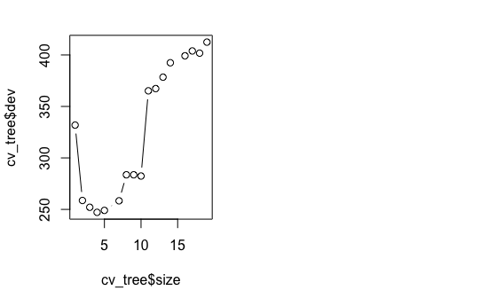

```r
#c
par(mfrow=c(1, 2))
plot(cv_tree$size, cv_tree$dev, type="b")
```

```r
#plot(cv_tree$k, cv_tree$dev, type="b")
```

### Step 6

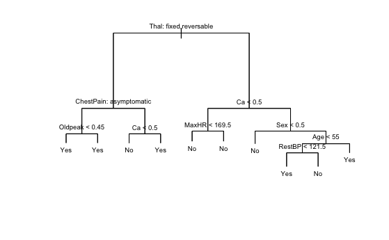

```r
#a
tree_pruned <- prune.tree(dtreeheart, best=10)
#b
plot(tree_pruned)
text(tree_pruned, cex=.6, pretty=0)
```

### Step 7

```r
#a
p5 <- predict(tree_pruned, newdata=test_heart, type="class")
#d
accuracy4 <- mean(p5==test_heart$AHD)
print(accuracy4)
```

```
[1] 0.7666667
```

# Problem 1 Answers

1. The most important variables were student and balance, whereas income was not.
2. The accuracy of the logistic model was 97.75 and 97.65 for the decision tree model.
3. The nodes of the decision tree shift from before observation to being observed and then creating the right node. Therefore, the left node was “No” before observing, and remained "No after observing.
4. If the inequality condition is satisfied and holds majority, it goes towards the right, if not satisfied and is the minority, it goes in the left node.
5. No, it is not necessary to prune this tree as it is not highly sensitive to variance. The tree shows a consistent form of responses and therefore it is not likely that the data is going to overfit.

# Problem 2 Answers

1. Important variables include Sex, ChestPainnonanginal, Chestpaintypical, and Ca.
2. “Thal”,“ChestPain”,“Oldpeak”,“MaxHR”,“RestBP”,“Ca”,“Chol”,“Age”,“Sex”,“Fbs”,“Slope” are the variables using in decision tree.
3. The logistic regression’s accuracy was .16667 whereas the one for the decision tree was .8. These clearly had a drastic change in accuracy when comparing, as expected.
4. The accuracy of the pruned tree was .7667
5. Decision tree might be more efficient for a doctor as since the relationships are so complex in this specific data set, decision trees will outperform logistic relations.